# Building predictive models with the mlr framework

We can also evaluate the tuning effect by visualizing the decision boundaries for the two models (limited to just two predictors)

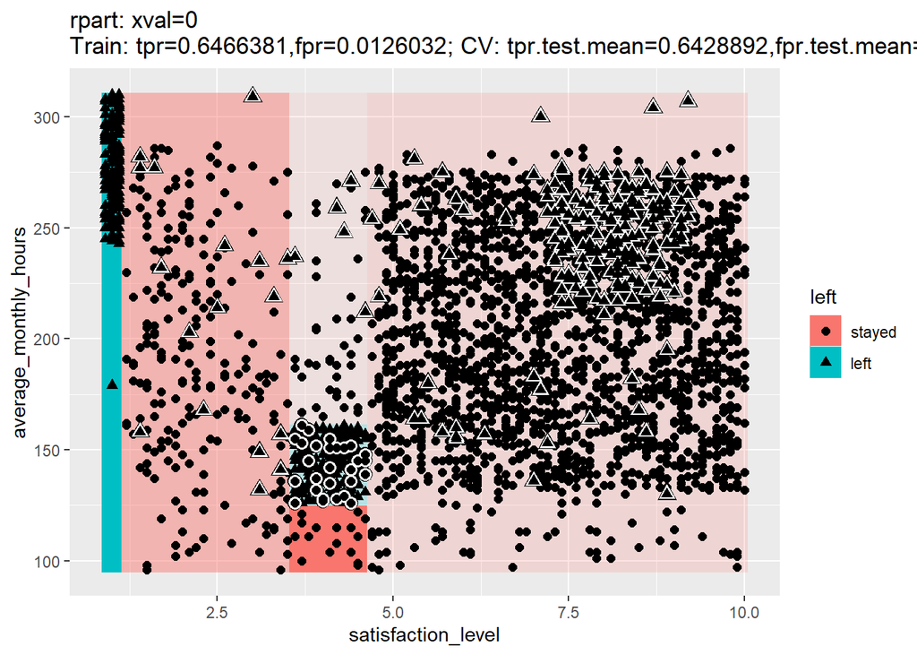

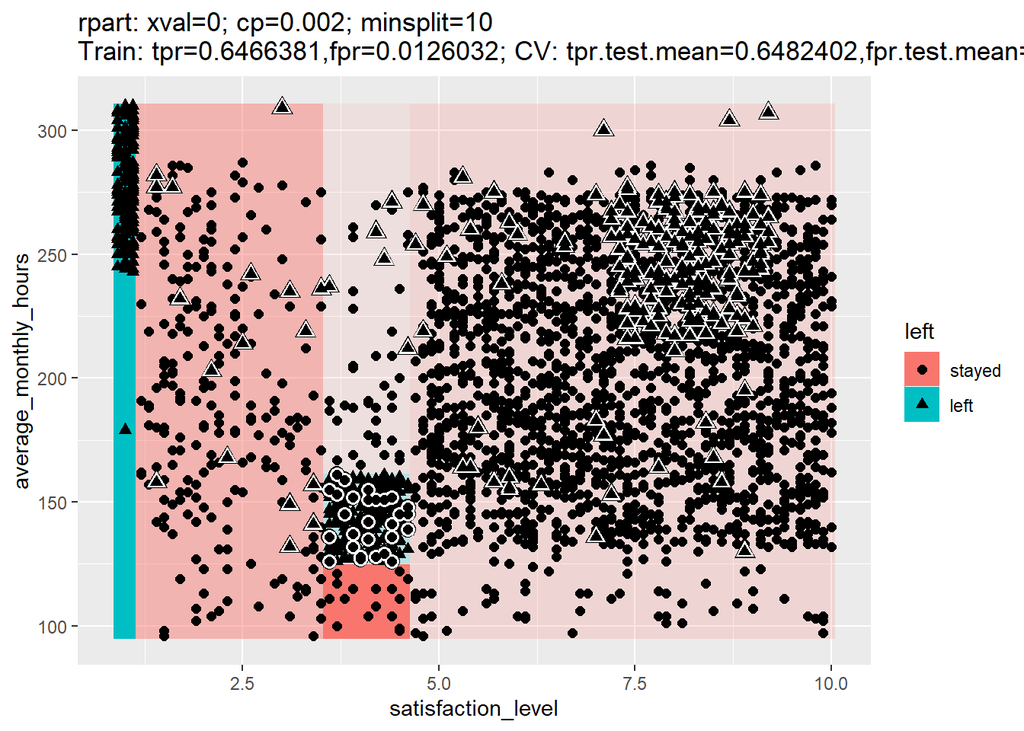

```r
list(rpart = turnover_rpart,
     rpart_opt = turnover_rpart_opt) %>%
  lapply(plotLearnerPrediction,
         task = turnover_task,
         features = c("satisfaction_level",
                      "average_monthly_hours"),
         measures = list(tpr, fpr))
```

When using 2 predictors, the tuned model is identical to the initial model.

# Resources

- Recording of Bernd Bishl’s master class on OpenML + R + mlr https://www.youtube.com/watch?v=rzjkT1uLNi4&t=672s
- MLR Tutorial, online https://mlr.mlr-org.com/articles/tutorial/task.html (см. меню Basics и Advanced в верхней части страницы)
- MLR Tutorial, pdf https://arxiv.org/abs/1609.06146
- What to do when you get an error caused by new factor levels when forecasting https://github.com/mlr-org/mlr/issues/811
- The list of learners available in mlr https://mlr.mlr-org.com/articles/tutorial/integrated_learners.html
- Tuning the hyperparameters: https://mlr.mlr-org.com/articles/tutorial/tune.html and https://mlr.mlr-org.com/articles/tutorial/hyperpar_tuning_effects.html